# meth03_analyze_data

SHARP Epigenetics Bootcamp 2025

## Analyze methylation data

Using data preprocessed in our script: meth01_process_data.R

load the data

```r
load("data/processed.rda")
```

load packages

```r
options(warn=-1)
suppressPackageStartupMessages({
  library(DMRcate) # for regional analysis
  library(magrittr)
  library(data.table) # for fast aggregation of large data
  library(qqman) # for visualization of data
  library(stringi) # string manipulation
  library(IlluminaHumanMethylationEPICv2anno.20a1.hg38)
})
options(warn=0)
```

Code categorical variable as factors

```r
pheno$smoker %<>% factor
pheno$Sex    %<>% factor
```

## Running an Epigenome Wide Association

Here we run an EWAS on Smoking status (as a predictor of methylation)

```r
nCpG = dim(beta)[1]
nCpG
```

```
## [1] 895651
```

First we can run a linear regression on a single CpG that we have already picked

```r
CpG.name = "cg05575921"
pheno$CpG.level <- beta[CpG.name,]
```

Difference in methylation between smokers and non-smokers for this CpG  
some descriptive statistics

```r
pheno[,.(
   Min    = min   (CpG.level) %>% round(3)
  ,Mean   = mean  (CpG.level) %>% round(3)
  ,Median = median(CpG.level) %>% round(3)
  ,Max    = max   (CpG.level) %>% round(3)
  ,SD     = sd    (CpG.level) %>% round(3)
  ,.N),by=smoker] %>% knitr::kable(.)
```

| smoker | Min | Mean | Median | Max | SD | N |
| --- | --- | --- | --- | --- | --- | --- |
| 1 | 0.415 | 0.553 | 0.570 | 0.669 | 0.080 | 15 |
| 0 | 0.788 | 0.873 | 0.878 | 0.935 | 0.039 | 15 |

Difference in beta methylation values between Smokers and non smokers

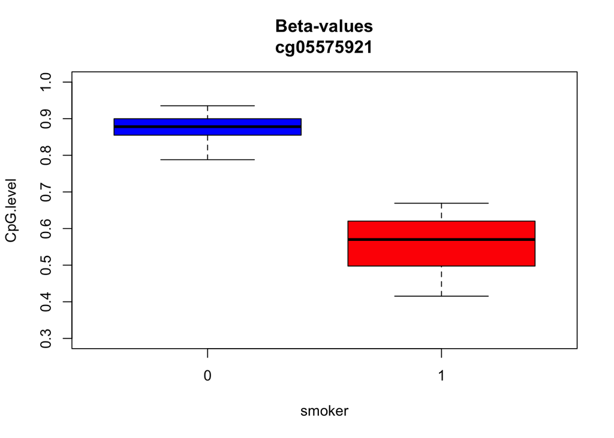

```r
boxplot(CpG.level ~ smoker,pheno,main=paste0("Beta-values\n", CpG.name), col=c("blue","red"),ylim=c(.3,1))
```

Linear regression on betas

```r
lm(CpG.level ~ smoker,data=pheno) %>% summary %>% coef
```

```
##               Estimate Std. Error   t value     Pr(>|t|)
## (Intercept)  0.8726141 0.01622247  53.79045 8.286065e-30
## smoker1     -0.3197268 0.02294204 -13.93629 4.044936e-14
```

Comparison with m-values

```r
pheno[,CpG.mlevel:=log2(CpG.level/(1-CpG.level))]

pheno[,.(
   Min    = min   (CpG.mlevel) %>% round(3)
  ,Mean   = mean  (CpG.mlevel) %>% round(3)
  ,Median = median(CpG.mlevel) %>% round(3)
  ,Max    = max   (CpG.mlevel) %>% round(3)
  ,SD     = sd    (CpG.mlevel) %>% round(3)
  ,.N),by=smoker] %>% knitr::kable(.)
```

| smoker | Min | Mean | Median | Max | SD | N |
| --- | --- | --- | --- | --- | --- | --- |
| 1 | -0.494 | 0.313 | 0.407 | 1.016 | 0.471 | 15 |
| 0 | 1.894 | 2.839 | 2.851 | 3.854 | 0.515 | 15 |

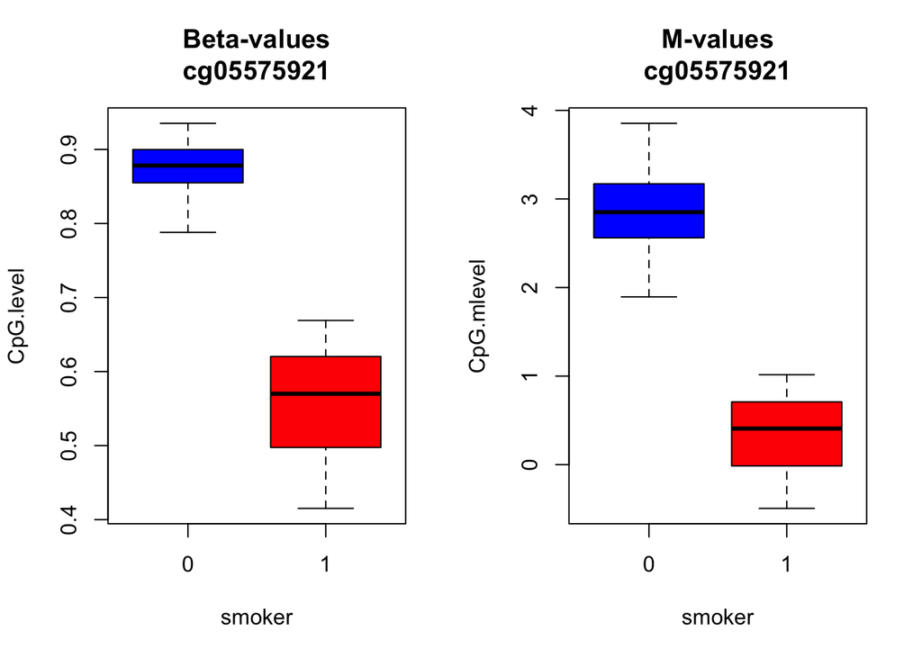

```r
par(mfrow=c(1,2))
boxplot(CpG.level  ~ smoker,data=pheno,main=paste0("Beta-values\n",CpG.name), col=c("blue","red"))
boxplot(CpG.mlevel ~ smoker,data=pheno,main=paste0("M-values\n"   ,CpG.name), col=c("blue","red"))
```

```r
dev.off()
```

linear regression on m-values

```r
lm(CpG.mlevel ~ smoker,data=pheno) %>% summary %>% coef
```

```
##              Estimate Std. Error   t value     Pr(>|t|)
## (Intercept)  2.839019  0.1273283  22.29685 2.300489e-19
## smoker1     -2.525886  0.1800693 -14.02730 3.446254e-14
```

We can always extract measures of the relative quality of statistical models - e.g. adjusted R2 - to look at model performance

model on betas

```r
lm(CpG.level  ~ smoker,data=pheno) %>% summary %$% adj.r.squared
```

```
## [1] 0.8694987
```

model on mvalues

```r
lm(CpG.mlevel ~ smoker,data=pheno) %>% summary %$% adj.r.squared
```

```
## [1] 0.8709764
```

## EWAS using limma

see [Smyth GK. Stat Appl Genet Mol Biol 2004](https://www.ncbi.nlm.nih.gov/pubmed/16646809).

```r
suppressMessages(library(limma,minfi))
```

Smoking as predictor  
note that limma is quite fast for running almost a million regressions!

```r
pheno[,smoke_dummy:=ifelse(smoker=="smoker",1,0)]
```

First we need to define a model

```r
model <- model.matrix( ~smoker,data=pheno) # simple bivariate model
EWAS.limma_model1 <- eBayes(lmFit(beta, design=model))
results1 <- topTable(EWAS.limma_model1, coef=2, number=Inf, sort.by="p", adjust.method="BH")
results1$ID <- row.names(results1)
```

here effect size is logFC among smokers compared to non-smokers for the top hits

```r
head(results1[, c(1, 2, 5)])
```

```
##                  logFC   AveExpr    adj.P.Val
## cg21566642 -0.24027253 0.4818249 1.793952e-09
## cg05575921 -0.31972683 0.7127507 1.793952e-09
## cg01940273 -0.13584138 0.6189500 1.731917e-07
## cg03636183 -0.13212329 0.6654279 2.171307e-06
## cg21161138 -0.09717609 0.6960448 3.529759e-05
## cg09945032 -0.08784690 0.3949316 3.698773e-05
```

check with previous result on our selected CpG (running lm without limma)

```r
subset(results1, results1$ID == CpG.name)
```

```
##                 logFC   AveExpr         t      P.Value    adj.P.Val        B
## cg05575921 -0.3197268 0.7127507 -14.43783 4.011481e-15 1.793952e-09 24.53034
##                    ID
## cg05575921 cg05575921
```

```r
summary(lm(CpG.level~smoker,pheno))$coefficients[2, ]
```

```
##      Estimate    Std. Error       t value      Pr(>|t|)
## -3.197268e-01  2.294204e-02 -1.393629e+01  4.044936e-14
```

The effect estimates are identical. However the test statistics and p-values differ slightly due to eBayes usage in the limma models

Bonferroni significant hits

```r
table(results1$P.Value < 0.05/(nCpG))
```

```
##
##  FALSE   TRUE
## 894389     20
```

FDR significant hits

```r
table(results1$adj.P.Val < 0.05)
```

```
##
##  FALSE   TRUE
## 894339     70
```

EWAS with adjustment for cell types  
now we can run the linear regression on betas adjusting for cell proportions

Need sex as indicator in covariate matrix

```r
model <- model.matrix( ~smoker+Sex+CD4+CD8+NK+B+MO,data=pheno)

EWAS.limma_model2 <- eBayes(lmFit(beta, design=model))
results2 <- topTable(EWAS.limma_model2, coef=2, number=Inf, sort.by="p", adjust.method="BH")
results2$ID <- row.names(results2)
head(results2[, c(1, 2, 5)])
```

```
##                  logFC   AveExpr    adj.P.Val
## cg05575921 -0.35012592 0.7127507 2.962507e-07
## cg21566642 -0.24778086 0.4818249 6.615005e-06
## cg25648203 -0.09825089 0.7595721 1.966819e-05
## cg01940273 -0.13491912 0.6189500 1.428576e-04
## cg03636183 -0.14346843 0.6654279 1.470774e-04
## cg17739917 -0.18921331 0.3986061 6.813355e-04
```

Using mvalues  
Use of M-values reduces heteroscedasticity to meet linear model assumptions  
See [Du P, et al. BMC Bioinformatics. 2010](https://pubmed.ncbi.nlm.nih.gov/21118553/).

```r
mvals <- ENmix::B2M(beta) # convert beta matrix to m-value matrix
EWAS.limma_model3 <- eBayes(lmFit(mvals, design=model))
results3 <- topTable(EWAS.limma_model3, coef=2, number=Inf, sort.by="p", adjust.method="BH")
head(results3[, c(1, 2, 5)])
```

```
##                 logFC    AveExpr    adj.P.Val
## cg05575921 -2.7644464  1.5760763 1.701599e-07
## cg21566642 -1.4781408 -0.1113726 1.031362e-05
## cg25648203 -0.7827486  1.6850190 1.031362e-05
## cg03636183 -0.9398868  1.0174950 1.419569e-04
## cg01940273 -0.8283904  0.7175651 3.310139e-04
## cg17739917 -1.1599477 -0.6205887 1.285061e-03
```

## Genomic inflation in EWAS

qqplot and lambda interpretation

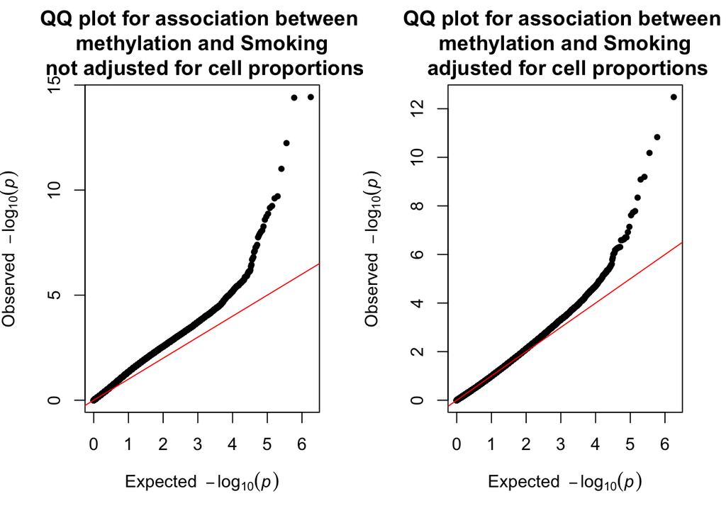

```r
par(mfrow=c(1,2))
qqman::qq(results1$P.Value, main = "QQ plot for association between \n methylation and Smoking \n not adjusted for cell proportions")
qqman::qq(results2$P.Value, main = "QQ plot for association between \n methylation and Smoking \n adjusted for cell proportions")
```

```r
dev.off()
```

Lambda - this is a summary measure of genomic inflation ratio of observed vs expected median p-value - is there early departure of the qqline estimated at -log10(median=0.5) ~ 0.3 on the x-axis of a qqplot

```r
lambda <- function(p) median(qchisq(p, df=1, lower.tail=FALSE), na.rm=TRUE) / qchisq(0.5, df=1)
```

Lambda before cell type adjustment

```r
lambda(results1$P.Value)
```

```
## [1] 1.459893
```

Lambda after cell type adjustment

```r
lambda(results2$P.Value)
```

```
## [1] 0.9021027
```

Lambda after cell type adjustment and using m-values

```r
lambda(results3$P.Value)
```

```
## [1] 0.9702668
```

## Bind results with annotation

```r
Annot <- as.data.frame(getAnnotation(IlluminaHumanMethylationEPICv2anno.20a1.hg38))
Annot <- subset(Annot, Annot$Name %in% manifest$ilmn_id)
Annot$ID <- substr(Annot$Name, 1, 10)
results2 <- dplyr::left_join(results2, Annot, by = "ID")
results2 %>% dplyr::arrange(P.Value) %>% dplyr::select(ID, logFC, P.Value, UCSC_RefGene_Name) %>% head(n = 10)
```

```
##            ID       logFC      P.Value UCSC_RefGene_Name
## 1  cg05575921 -0.35012592 3.312250e-13
## 2  cg21566642 -0.24778086 1.479190e-11
## 3  cg25648203 -0.09825089 6.597046e-11
## 4  cg01940273 -0.13491912 6.388916e-10
## 5  cg03636183 -0.14346843 8.222043e-10             F2RL3
## 6  cg17739917 -0.18921331 4.570631e-09
## 7  cg14817490 -0.10950939 1.635869e-08
## 8  cg00501876 -0.05035942 1.871637e-08
## 9  cg21161138 -0.10598704 2.432811e-08
## 10 cg10558063 -0.07843738 7.283083e-08
```

Volcano Plot-results2

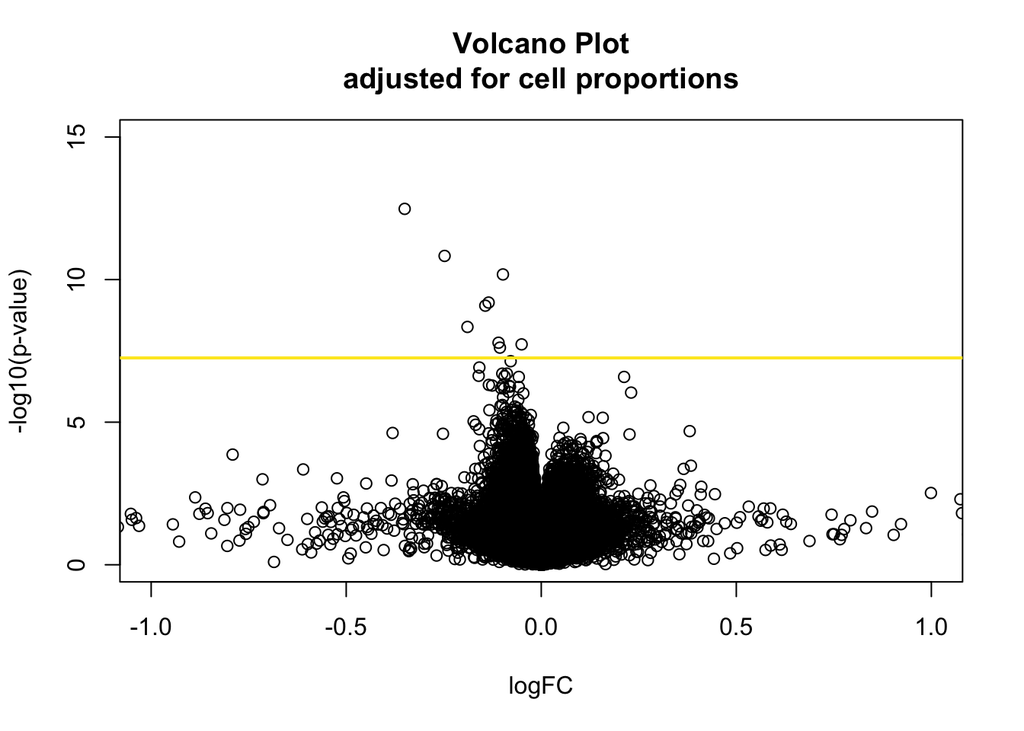

```r
plot(-log10(P.Value) ~ logFC, data=results2, xlab="logFC", ylab="-log10(p-value)",
     main="Volcano Plot\nadjusted for cell proportions",xlim = c(-1,1), ylim=c(0,15))
abline(h = -log10(0.05/(nCpG)), lty=1, col="#FDE725FF", lwd=2)
```

Manhattan plot for cell-type adjusted EWAS

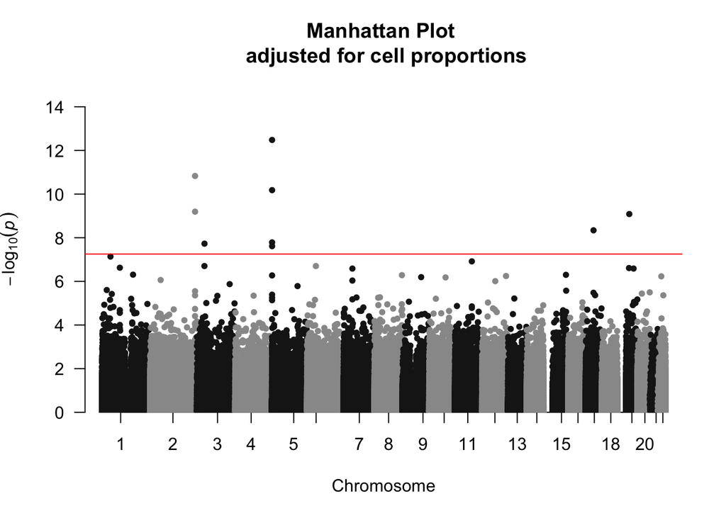

```r
results2$chr <- as.numeric(gsub("chr", "", results2$chr))
qqman::manhattan(results2,chr="chr", bp="pos", p="P.Value", snp="ID"
   ,suggestiveline=FALSE, genomewideline = -log10(0.05/(nCpG)), ylim=c(0,15)
   ,main = "Manhattan Plot \n adjusted for cell proportions")
```

## Introduction to pathway analysis with gometh

see [Geeleher et al. Bioinformatics 2013](https://academic.oup.com/bioinformatics/article/29/15/1851/265573?login=false).  
Using all FDR significant associations from the cell-adjusted model as input

```r
library(missMethyl)
keggResult = gometh(sig.cpg = results2$ID[results2$adj.P.Val < 0.05],
                    all.cpg = results2$ID, collection = 'KEGG')
```

```
## All input CpGs are used for testing.
```

```r
keggResult = keggResult[order(keggResult$P.DE),]
head(keggResult)
```

```
##                                  Description   N DE         P.DE       FDR
## hsa04640          Hematopoietic cell lineage  91  2 0.0009759317 0.3571910
## hsa04660   T cell receptor signaling pathway 115  2 0.0025895695 0.4738912
## hsa04614            Renin-angiotensin system  20  1 0.0081640901 0.9960190
## hsa00480              Glutathione metabolism  49  1 0.0251370784 1.0000000
## hsa04610 Complement and coagulation cascades  81  1 0.0327875283 1.0000000
## hsa04664     Fc epsilon RI signaling pathway  66  1 0.0405269229 1.0000000
```

Other tools for running EWAS  
**CpGassoc**  
See [Barfield et al. Bioinformatics 2012](http://www.ncbi.nlm.nih.gov/pubmed/22451269)  
See previous version of the bootcamp for examples  
https://github.com/D-Khodasevich/EBC_Summer_2024

**Efficient EWAS using meffil**  
See [meffil GitHub page](https://github.com/perishky/meffil)  
Options for running robust linear regression

```r
ewas.rlm<-meffil.ewas(beta, variable=pheno$smoker,
                      covariates=pheno[,c('Sex','CD4','CD8','NK','MO','GR','B')], rlm = TRUE)
```

clear environment

```r
rm(list = ls()); gc()
```

```
##             used   (Mb) gc trigger   (Mb) limit (Mb)  max used   (Mb)
## Ncells  27181079 1451.7   40019875 2137.3         NA  32451780 1733.2
## Vcells 347231436 2649.2  895549294 6832.5      65536 746224400 5693.3
```

End of script 03